# Analysis of Road Accidents to minimize future possibilities for Road mishaps

### Data Exploration

Now that we are done with data cleansing, we move to data exploration. Here we check our data. We try to answer our initial questions. We find which year has the most accidents or how many were alcohol/drug related accidents etc.

#### 2a. Checking which year has the highest accidents

```r
# group accidents by year and count the number of accidents in each year
year_counts <- new_data %>%
                group_by(year) %>%
                summarise(accident_count = n())

# sort the years by the number of accidents in descending order
year_counts <- year_counts[order(-year_counts$accident_count),]

# print the year with the highest number of accidents
cat("The year with the highest number of accidents is", year_counts$year[1], "with", year_counts$accident_count[1], "accidents.")
```

```
## The year with the highest number of accidents is 2016 with 52393 accidents.
```

#### 2b. Checking which age group has highest accidents

```r
# create age groups based on the age column
new_data <- new_data %>%
  mutate(age_group = cut(prty_age, breaks = c(0, 15, 30, 45, 61, Inf),
                         labels = c("0-15", "16-30", "31-45", "46-60","61+")))

# group accidents by age group and count the number of accidents in each group
age_counts <- new_data %>% group_by(age_group) %>% summarise(accident_count = n())

# sort the age groups by the number of accidents in descending order
age_counts <- age_counts[order(-age_counts$accident_count),]

# print the age group with the highest number of accidents
cat("The age group with the highest number of accidents is", age_counts$age_group[1], "with", age_counts$accident_count[1], "accidents.")
```

```
## The age group with the highest number of accidents is 2 with 123210 accidents.
```

#### 2c.Data with fatal accidents only

```r
fatal_accidents <- new_data %>%
        filter(injy_svty_cd == "1")
#View(fatal_accidents)
```

#### 2d. Finding which year has the most fatal accidents

```r
fatal_by_year <- fatal_accidents %>%
  group_by(year) %>%
  summarize(num_fatal = n())

# Find the year with the most fatal accidents
most_fatal_year <- fatal_by_year %>%
  filter(num_fatal == max(num_fatal))

print(most_fatal_year)
```

```
## # A tibble: 2 × 2
##    year num_fatal
##   <int>     <int>
## 1  2010        77
## 2  2016        77
```

#### 2e. How many percentage of accidents happen in Clear weather(Value =1) and dry road conditions(value=1)

```r
total_accidents <- nrow(new_data)
clear_wthr_crash <- sum(new_data$wthr_cd == 1, na.rm = TRUE)
percent_clear_wthr_crash <- 100 * clear_wthr_crash / total_accidents
print(percent_clear_wthr_crash)# 49%
```

```
## [1] 49.66906
```

```r
clear_rd_crash<-sum(new_data$rd_cond_cd == 1, na.rm = TRUE)
percent_clear_rd_crash <- 100 * clear_rd_crash / total_accidents
print(percent_clear_rd_crash) # 62%
```

```
## [1] 62.86786
```

#### 2f. How many percentage were under alc or drug influence.

```r
alc_drug_crash<-sum(new_data$alc_drug == 1, na.rm = TRUE)
percent_alc_drug_crash <- 100 * alc_drug_crash / total_accidents
print(percent_alc_drug_crash) # 1.9%%
```

```
## [1] 1.918437
```

#### 2g. How severe were alc_drug accidents

```r
alc_drug_data_fatal <- subset(new_data, injy_svty_cd == 1)
total_alc_drug_accidents <- nrow(alc_drug_data_fatal)
alc_drug_crash_fatal<-sum(alc_drug_data_fatal$alc_drug == 1, na.rm = TRUE)
percent_alc_drug_crash_fatal <- 100 * alc_drug_crash_fatal / total_alc_drug_accidents
print(percent_alc_drug_crash_fatal) #31% of alc_drug accidents are fatal
```

```
## [1] 31.1245
```

#### 2h. How severe were other accidents without alc_drug

```r
accidents_wo_alc_drug <- new_data %>%
  filter(alc_drug == 0)

count_wo_alc_drug<-nrow(accidents_wo_alc_drug)
wo_alc_drug_crash_fatal<-sum(accidents_wo_alc_drug$injy_svty_cd == 1, na.rm = TRUE)
percent_wo_alc_drug_crash_fatal <- 100 * wo_alc_drug_crash_fatal / count_wo_alc_drug
print(percent_wo_alc_drug_crash_fatal) #0.1% of total accidents are fatal without alc_drug
```

```
## [1] 0.1073603
```

Now that we have extracted some information about our data and have learned some insights, we now more to the visual part of our data. Visualization gives us an understanding of our data in pictorial form. It allows us to see a bigger pattern of the data. We will plot graphs, scatterplot and heatmap to see how our data is.

### 3 Data Visualisation Part 1

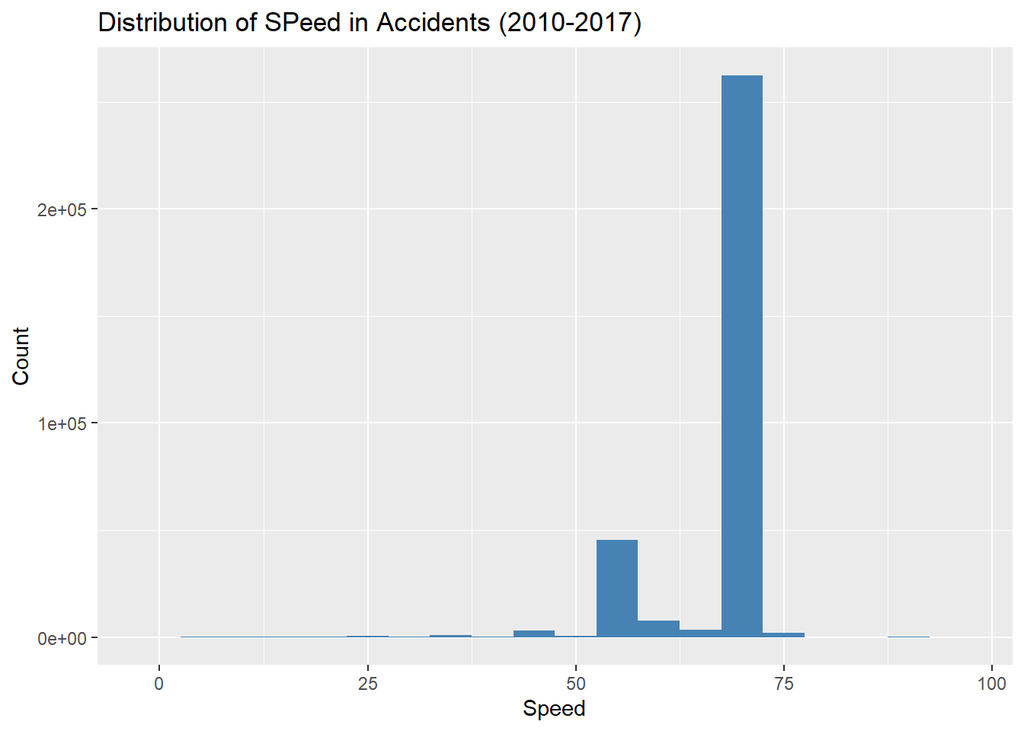

```r
ggplot(new_data, aes(x = spd_limt)) +
  geom_histogram(binwidth = 5, fill = "steelblue") +
  labs(title = "Distribution of SPeed in Accidents (2010-2017)",
       x = "Speed",
       y = "Count")
```

From this graph, we learn most accidents happen at speed limit around 70. There are some too at 50 to 60 too.

#### 3a. Check distribution of Age

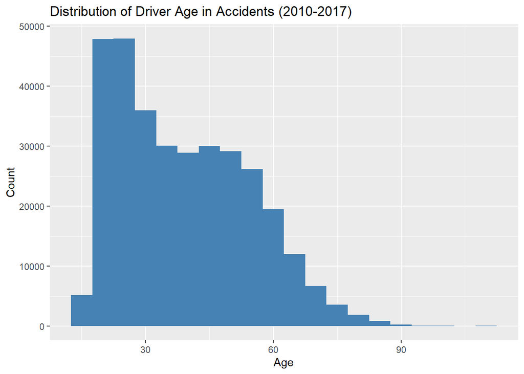

```r
ggplot(new_data, aes(x = prty_age)) +
  geom_histogram(binwidth = 5, fill = "steelblue") +
  labs(title = "Distribution of Driver Age in Accidents (2010-2017)",
       x = "Age",
       y = "Count")
```

This graph shows us the pattern of age with respect to accidents. Around 18-28 years old has most accidents. After that the number of accidents tend to decrease as the age starts increasing.

#### 3c checking trends on accidents by year

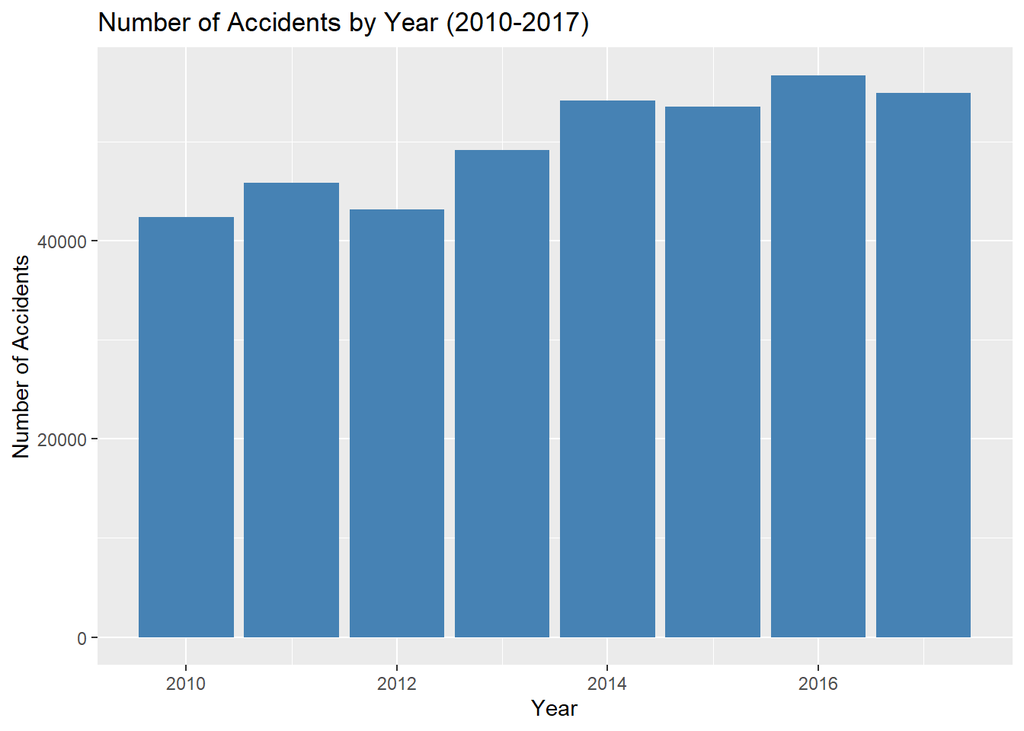

```r
ggplot(NA_data, aes(x = year)) +
  geom_bar(fill = "steelblue") +
  labs(title = "Number of Accidents by Year (2010-2017)",
       x = "Year",
       y = "Number of Accidents")
```

```r
#we use 2013 data too just to see the pattern
```

#### 3d. Alcohol and drug related accidents over the years

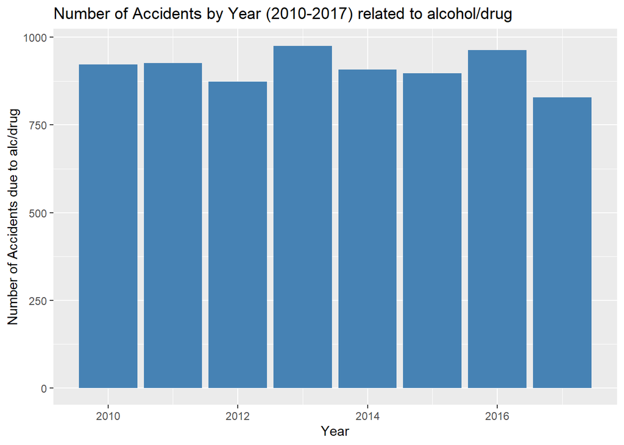

```r
alc_dru_data<-subset(NA_data,alc_drug==1)
ggplot(alc_dru_data, aes(x = year)) +
  geom_bar(fill = "steelblue") +
  labs(title = "Number of Accidents by Year (2010-2017) related to alcohol/drug",
       x = "Year",
       y = "Number of Accidents due to alc/drug")
```

Alcohol and drug related accidents tend to be uniform throughout the year.

#### 3e Most accident occurrence by time

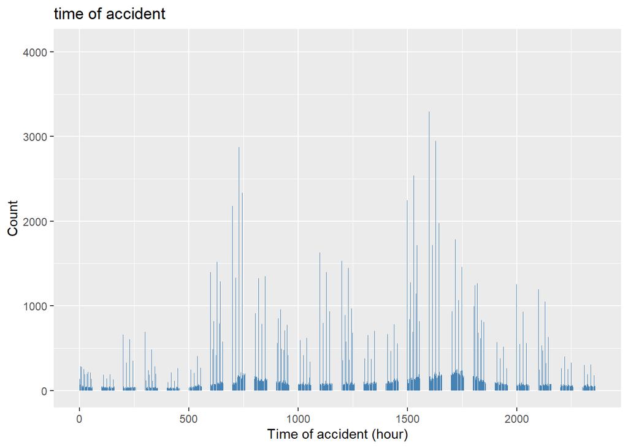

```r
ggplot(new_data, aes(x = milt_time)) +
  geom_bar(fill = "steelblue") +
  labs(x = "Time of accident (hour)", y = "Count", title = "time of accident")
```

#### 3f. Checking road accidents by road condition

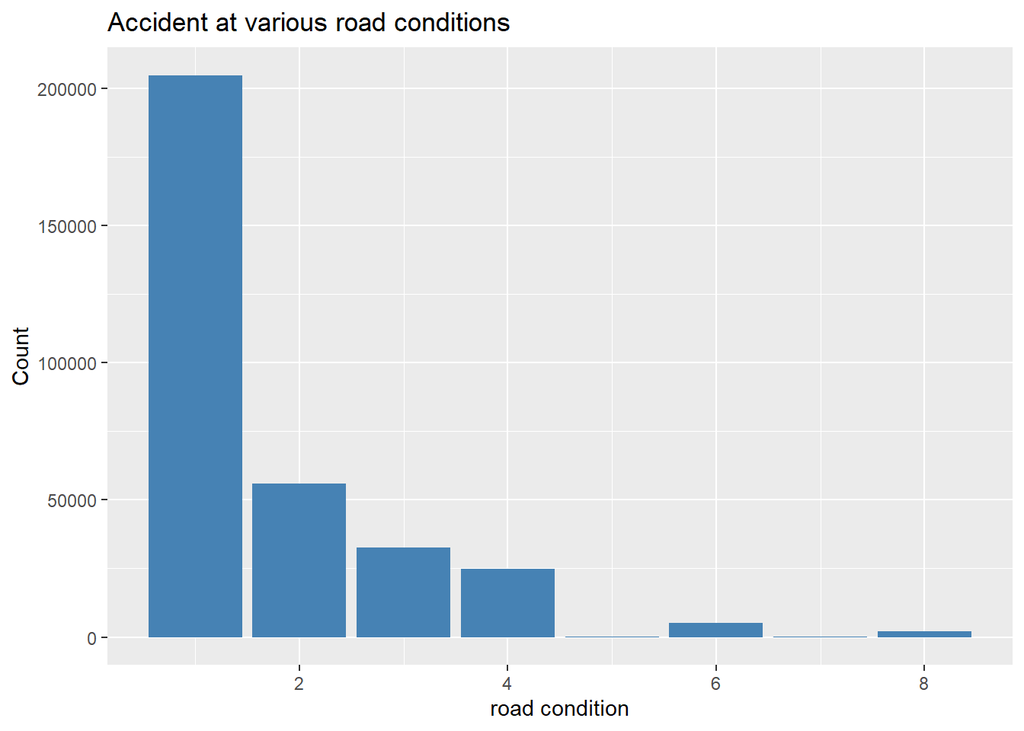

```r
ggplot(new_data, aes(x = rd_cond_cd)) +
  geom_bar(fill = "steelblue") +
  labs(x = "road condition", y = "Count", title = "Accident at various road conditions")
```

This graph shows the number of accidents on various road conditions. The road conditions are numbered from 1 to 8. 1 Dry 2 Wet 3 Icy 4 Snowy 5 Muddy 6 Slushy 7 Covered with debris 8 Other/unknown

The graph shows that bad road conditions don’t necessarily contribute to accidents. Most accidents occur at ideal (dry) road condition.This explains that people tend to do driver more careful at bad road conditions.

#### 3g. Accident at various Weather conditions

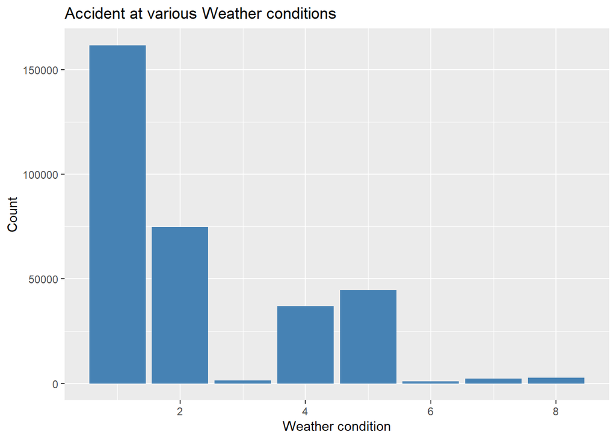

```r
ggplot(new_data, aes(x = wthr_cd)) +
  geom_bar(fill = "steelblue") +
  labs(x = "Weather condition", y = "Count", title = "Accident at various Weather conditions")
```

Clear day(1) has high chances of accident, just like in ideal road condition. cloudy(2),rain(4) and snow(5) together contribute nearly as equal to clear sky accidents.

#### 3h. Accident at various light conditions

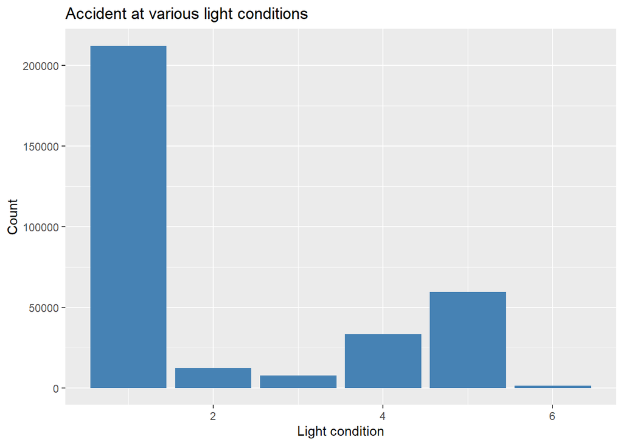

```r
#3h Accident at various light conditions
ggplot(new_data, aes(x = lit_cd)) +
  geom_bar(fill = "steelblue") +
  labs(x = "Light condition", y = "Count", title = "Accident at various light conditions")
```

Daylight(1) accidents has most occurence. Dark without strretlight(5) has more accidents than dark with streetlight(4)

#### 3i Accident at various injury severity

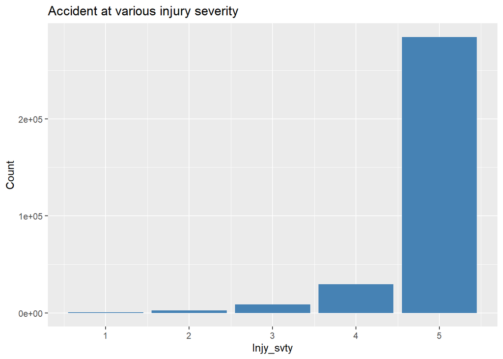

```r
#3i Accident at various injury severity
ggplot(new_data, aes(x = injy_svty_cd )) +
  geom_bar(fill = "steelblue") +
  labs(x = "Injy_svty", y = "Count", title = "Accident at various injury severity")
```

Most accidents are not fatal, though few are incapacitating(2) and non-incapacitating(3)

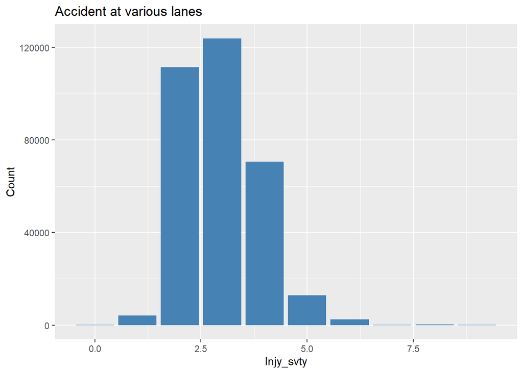

```r
ggplot(new_data, aes(x = num_lns )) +
  geom_bar(fill = "steelblue") +
  labs(x = "Injy_svty", y = "Count", title = "Accident at various lanes")
```

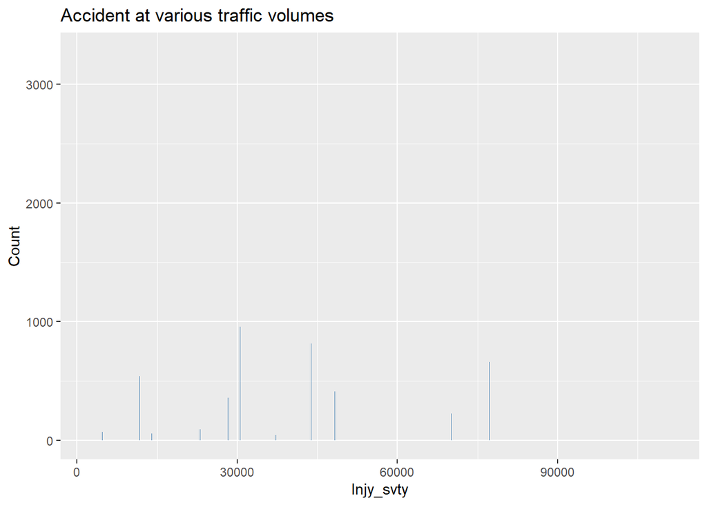

```r
ggplot(new_data, aes(x = traffic_volume )) +
  geom_bar(fill = "steelblue") +
  labs(x = "Injy_svty", y = "Count", title = "Accident at various traffic volumes")
```

Now we try to explore alcohol/drug related accidents by adding to speed limit accidents.

```r
# Grouping the accidents data by speed limit and alcohol/Drug use
speed_alcohol <- new_data %>%
  group_by(spd_limt, alc_drug) %>%
  summarize(count = n())
```

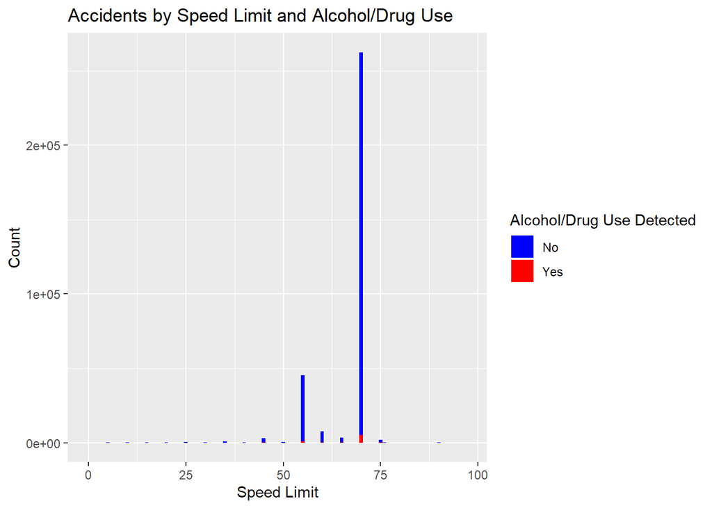

```r
# Create a stacked bar chart
ggplot(speed_alcohol, aes(x = spd_limt, y = count, fill = factor(alc_drug))) +
  geom_bar(stat = "identity") +
  labs(title = "Accidents by Speed Limit and Alcohol/Drug Use",
       x = "Speed Limit", y = "Count") +
  scale_fill_manual(name = "Alcohol/Drug Use Detected",
                    values = c("blue", "red"),
                    labels = c("No", "Yes"))
```

Speed limit 70 has a lot of accidents related to both with and without alcohol/drug related accidents.

### 3 Data Visualisation Part 2

#### 3.a

We now plot a scatterplot between time of accident and age of driver with alcohol/drug related accidents taken into account.

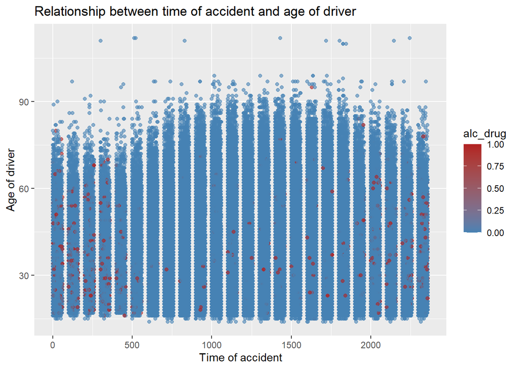

```r
ggplot(new_data, aes(x = milt_time, y = prty_age, color = alc_drug)) +
  geom_point(alpha = 0.6) +
  scale_color_gradient(low = "steelblue", high = "firebrick") +
  labs(x = "Time of accident", y = "Age of driver", title = "Relationship between time of accident and age of driver")
```

Looking at the scatterplot, we find that Alc_drug accidents seem to happen more between 8pm to 3 am as shown by the red dots. Also more age groups tend to travel between 10 am to 3 pm(camel-like hump in the middle of the plot)

#### 3.b

We plot another scatter plot of traffic volume by age of driver, colored by alc_drug use.

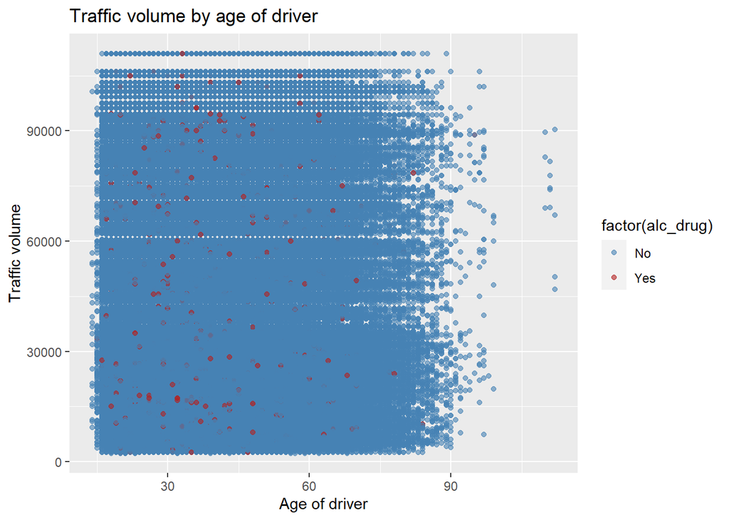

```r
ggplot(new_data, aes(x = prty_age, y = traffic_volume, color = factor(alc_drug))) +
  geom_point(alpha = 0.6) +
  labs(x = "Age of driver", y = "Traffic volume", title = "Traffic volume by age of driver") +
  scale_color_manual(values = c("steelblue", "firebrick"), labels = c("No", "Yes")) #low traffic volume and low age more accidents, alcohol not reqd
```

This confirms that alcohol/drug related accidents happen more in lower age groups(notice that most red dots lie around 18 to 40). Also accidents occur more in less traffic area. Higher traffic volumes tend to have less accidents as compared to lower traffic volume.

#### 3.c Scatter plot of traffic volume by injury severity with alc/drug usage taken into account

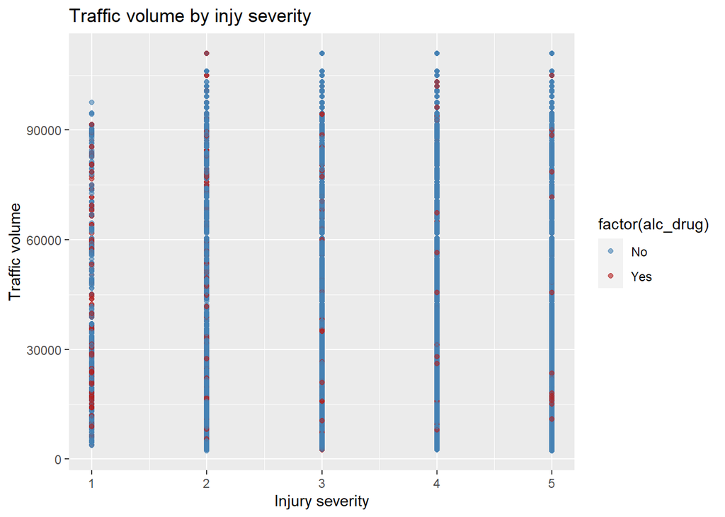

```r
ggplot(new_data, aes(x = injy_svty_cd, y = traffic_volume, color = factor(alc_drug))) +
  geom_point(alpha = 0.6) +
  labs(x = "Injury severity", y = "Traffic volume", title = "Traffic volume by injy severity") +
  scale_color_manual(values = c("steelblue", "firebrick"), labels = c("No", "Yes"))
```

The above scatterplot shows that alcohol/drug accidents are usually related to high injury severity(1 is fatal)(notice the intensity of red dot of 1 as copared to 2,3,4 and 5)

### 3 Data Visualisation Part 3

For our last part of data visualisation, we will apply heatmaps on Road and Weather condition and Road and Light conditions.

#### 3.a Heatmap of Accidents by Road and Weather Condition

```r
#Group the data by road condition and weather condition, and count the number of accidents in each group
accidents_grouped <- new_data %>%
  group_by(rd_cond_cd, wthr_cd) %>%
  summarise(count = n()) %>%
  ungroup()
```

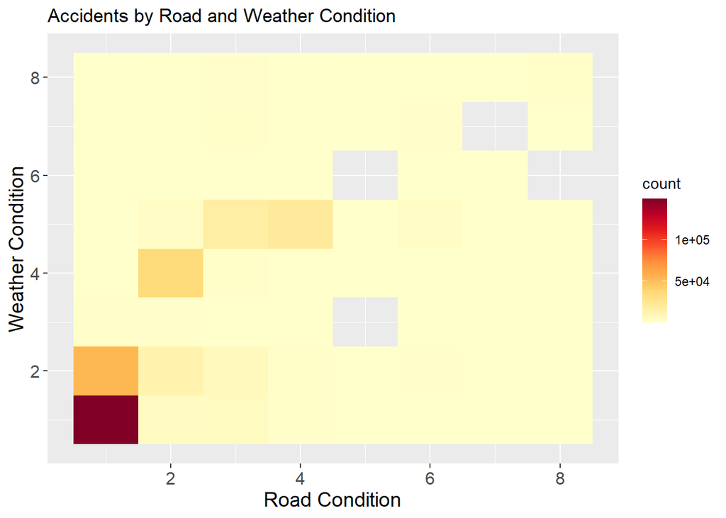

```r
# Create a heatmap
ggplot(accidents_grouped, aes(x = rd_cond_cd, y = wthr_cd, fill = count)) +
  geom_tile() +
  scale_fill_gradientn(colours = brewer.pal(9, "YlOrRd"), na.value = "firebrick") +
  labs(x = "Road Condition", y = "Weather Condition", title = "Accidents by Road and Weather Condition") +
  theme(axis.title = element_text(size = 14), axis.text = element_text(size = 12))
```

This heatmap shows that accident occur the most at good weather and good road conditions. Notice the intense red at low value of both.

#### 3.b Heatmap of Accidents by Road and light Condition

```r
accidents_grouped <- new_data %>%
  group_by(rd_cond_cd, lit_cd) %>%
  summarise(count = n()) %>%
  ungroup()
```

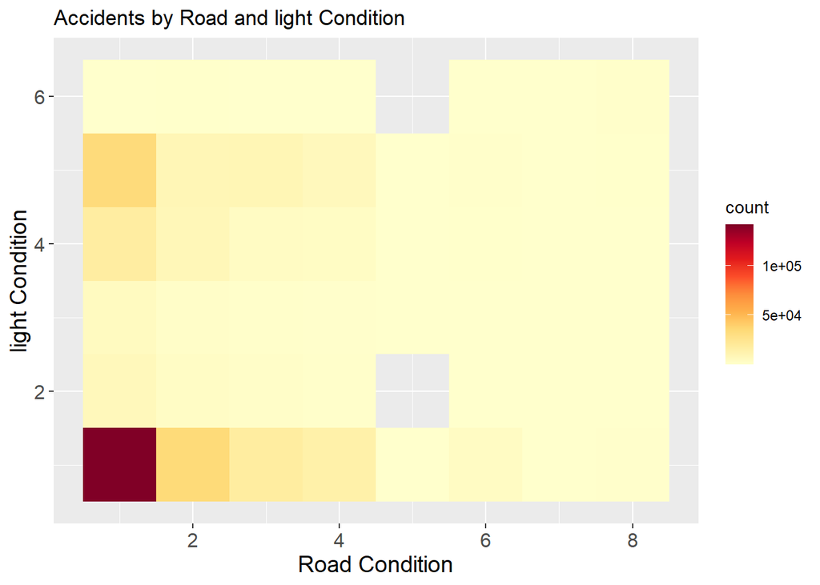

```r
# Create a heatmap
ggplot(accidents_grouped, aes(x = rd_cond_cd, y = lit_cd, fill = count)) +
  geom_tile() +
  scale_fill_gradientn(colours = brewer.pal(9, "YlOrRd"), na.value = "firebrick") +
  labs(x = "Road Condition", y = "light Condition", title = "Accidents by Road and light Condition") +
  theme(axis.title = element_text(size = 14), axis.text = element_text(size = 12))
```

This heatmap shows that accident occur the most at good light and good road conditions. Notice the dark red at low value.

### 4 Machine Learning:

For the last part of our project, we will apply machine learning. We will develop an algorithm by training 80% of our dataset. Then predict using the rest of the data. Then we will our algorithm accuracy, Confidence interval and other parameters.

```r
library(ggplot2)
#install.packages("ggcorrplot")
library(ggcorrplot)
#install.packages("FactoMineR")
library("FactoMineR")

#*#Make sure all the below libraries are up to date.
#*If you aren't sure then 'Remove' and 'Install' again
#*Remove by using "remove.packages("name_of_library")""
#*Install by using "install.packages("name_of_library")"


#install.packages('caret')
#install.packages('lattice')
library(rlang)
library(lattice)
library(caret)
library(MASS)
#remove.packages("vctrs")
#install.packages("rlang")
#remove.packages("vctrs")
#install.packages("vctrs")
#remove.packages("tibble")
#install.packages("tibble")
```

#### 4.b Loading data and getting some hindsight

```r
accident_data<-new_data[,c(1:11)] #Removing the last three columns which was created from previous Data wrangling
#summary

head(accident_data)
```

|  | injy_svty_cd | milt_time | wthr_cd | lit_cd | rd_cond_cd | num_lns | spd_limt | prty_age | year | traffic_volume | alc_drug |
| --- | --- | --- | --- | --- | --- | --- | --- | --- | --- | --- | --- |
| 1 | 5 | 218 | 5 | 5 | 4 | 2 | 70 | 17 | 2010 | 6699 | 0 |
| 2 | 5 | 218 | 5 | 5 | 4 | 2 | 70 | 59 | 2010 | 6699 | 0 |
| 4 | 5 | 120 | 5 | 4 | 4 | 3 | 70 | 22 | 2010 | 43750 | 1 |
| 6 | 5 | 1542 | 1 | 1 | 1 | 3 | 70 | 42 | 2010 | 56423 | 0 |
| 7 | 5 | 1000 | 2 | 1 | 3 | 2 | 70 | 21 | 2010 | 19321 | 0 |
| 8 | 4 | 1245 | 5 | 1 | 3 | 2 | 70 | 39 | 2010 | 18050 | 0 |

```r
summary(accident_data)
```

```
##   injy_svty_cd     milt_time       wthr_cd          lit_cd        rd_cond_cd
##  Min.   :1.000   Min.   :   0   Min.   :1.000   Min.   :1.000   Min.   :1.00
##  1st Qu.:5.000   1st Qu.: 826   1st Qu.:1.000   1st Qu.:1.000   1st Qu.:1.00
##  Median :5.000   Median :1400   Median :2.000   Median :1.000   Median :1.00
##  Mean   :4.826   Mean   :1297   Mean   :2.243   Mean   :2.138   Mean   :1.73
##  3rd Qu.:5.000   3rd Qu.:1730   3rd Qu.:4.000   3rd Qu.:4.000   3rd Qu.:2.00
##  Max.   :5.000   Max.   :2359   Max.   :8.000   Max.   :6.000   Max.   :8.00
##     num_lns         spd_limt        prty_age           year
##  Min.   :0.000   Min.   : 0.00   Min.   : 14.00   Min.   :2010
##  1st Qu.:2.000   1st Qu.:70.00   1st Qu.: 25.00   1st Qu.:2012
##  Median :3.000   Median :70.00   Median : 37.00   Median :2014
##  Mean   :2.958   Mean   :67.18   Mean   : 38.94   Mean   :2014
##  3rd Qu.:4.000   3rd Qu.:70.00   3rd Qu.: 51.00   3rd Qu.:2016
##  Max.   :9.000   Max.   :97.00   Max.   :112.00   Max.   :2017
##  traffic_volume      alc_drug
##  Min.   :  2308   Min.   :0.00000
##  1st Qu.: 26113   1st Qu.:0.00000
##  Median : 48400   Median :0.00000
##  Mean   : 50390   Mean   :0.01918
##  3rd Qu.: 74650   3rd Qu.:0.00000
##  Max.   :111047   Max.   :1.00000
```

```r
str(accident_data)
```

```
## 'data.frame':    325734 obs. of  11 variables:
##  $ injy_svty_cd  : int  5 5 5 5 5 4 5 5 5 5 ...
##  $ milt_time     : num  218 218 120 1542 1000 ...
##  $ wthr_cd       : int  5 5 5 1 2 5 5 5 5 5 ...
##  $ lit_cd        : int  5 5 4 1 1 1 1 1 1 1 ...
##  $ rd_cond_cd    : int  4 4 4 1 3 3 4 3 3 4 ...
##  $ num_lns       : int  2 2 3 3 2 2 2 2 2 2 ...
##  $ spd_limt      : int  70 70 70 70 70 70 70 70 70 70 ...
##  $ prty_age      : int  17 59 22 42 21 39 21 26 44 34 ...
##  $ year          : int  2010 2010 2010 2010 2010 2010 2010 2010 2010 2010 ...
##  $ traffic_volume: int  6699 6699 43750 56423 19321 18050 18058 18058 18058 18050 ...
##  $ alc_drug      : num  0 0 1 0 0 0 0 0 0 0 ...
```

```r
#View(accident_data)
```

#### 4.c

We now prepare our data for ML by doing Data normalization and scaling. For our data we use injury severity level(injy_svty_cd) as our dependent variable. We also Plot the correlation matrix of each variables.

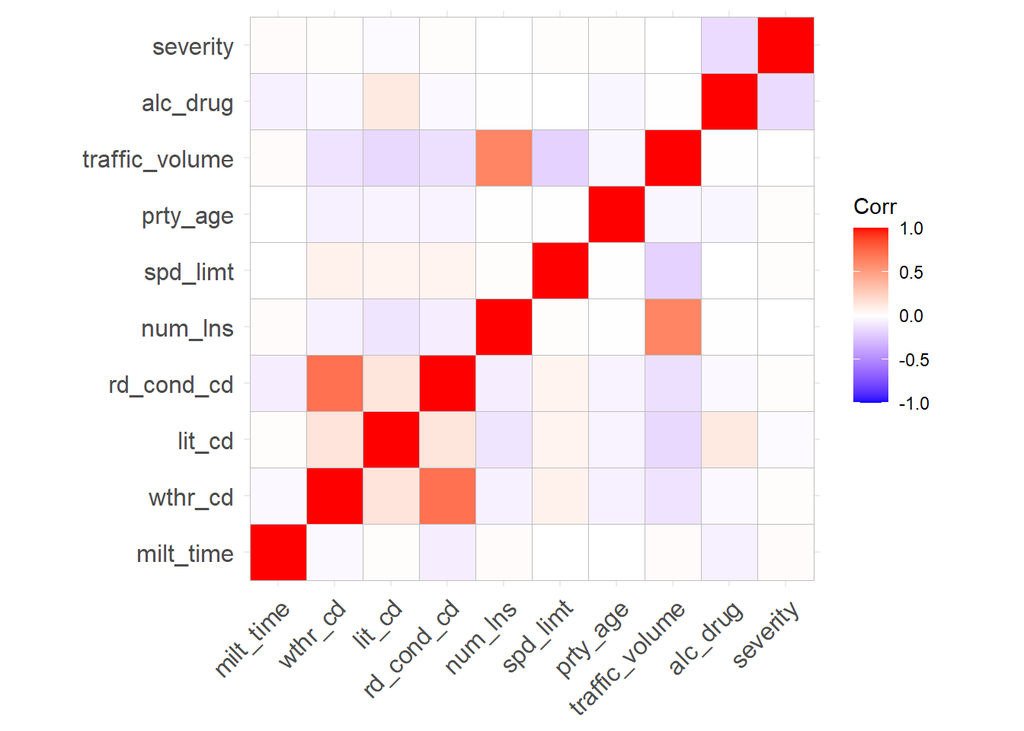

```r
# year is removed
data_for_normalization<-accident_data[,c(2:8,10:11)]

#importing Severity injury condition into "severity"
severity<-c(accident_data$injy_svty_cd)

data_normalized<-scale(data_for_normalization)
data_normalized_df <- as.data.frame(data_normalized)

df<-data.frame(data_normalized_df,severity)
#df1<-data.frame(data_normalized_df,severity)

corr_matrix <- cor(df)


#correlation matrix
ggcorrplot(corr_matrix)
```

The correlation matrix shows that age is un-correlated(white and blue cubes only). The other variables have correlation (Red cubes or little shade of red)

#### 4.d

We now create a new categorical column based on the severity column. The values of severity as given by data are numeric. 1 being fatal, 2 being critical and so on. We have converted them into words

```r
df$severity <- ifelse(df$severity == 1, "fatal",
                      ifelse(df$severity == 2, "critical",
                             ifelse(df$severity == 3, "severe",
                                    ifelse(df$severity == 4, "moderate", "minor"))))

df$severity<-as.factor(df$severity)
top_df <- as.data.frame(df)
```

#### 4.e

We use ORDINAL LOGISTIC REGRESSION MODEL for our ML algorithm. Our dependent variable is Ordinal (rank based on scale, from high to low). ‘polr’ is the function for OLR. We also remove age(prty_age) from our model because it shows no correlation(as per our above corr matrix). Lastly we use confusion matrix to see our model

```r
set.seed(123)
train_indices<-sample(nrow(top_df),0.8*nrow(top_df)) #80% of data is used for training
train_data<-top_df[train_indices,]
test_data<-top_df[-train_indices,]

model <- polr(severity ~ wthr_cd +  lit_cd + num_lns + spd_limt + rd_cond_cd + alc_drug + traffic_volume , data = train_data)
# age removed since no correlation
test_preds <- predict(model, newdata = test_data, type = "class")
#type=class since classifctation algo


confusionMatrix(test_preds, test_data$severity)
```

```
## Confusion Matrix and Statistics
##
##           Reference
## Prediction critical fatal minor moderate severe
##   critical        0     0     0        0      0
##   fatal           0     0     0        0      0
##   minor         551   103 56699     6024   1770
##   moderate        0     0     0        0      0
##   severe          0     0     0        0      0
##
## Overall Statistics
##
##                Accuracy : 0.8703
##                  95% CI : (0.8677, 0.8729)
##     No Information Rate : 0.8703
##     P-Value [Acc > NIR] : 0.5029
##
##                   Kappa : 0
##
##  Mcnemar's Test P-Value : NA
##
## Statistics by Class:
##
##                      Class: critical Class: fatal Class: minor Class: moderate
## Sensitivity                 0.000000     0.000000       1.0000         0.00000
## Specificity                 1.000000     1.000000       0.0000         1.00000
## Pos Pred Value                   NaN          NaN       0.8703             NaN
## Neg Pred Value              0.991542     0.998419          NaN         0.90753
## Prevalence                  0.008458     0.001581       0.8703         0.09247
## Detection Rate              0.000000     0.000000       0.8703         0.00000
## Detection Prevalence        0.000000     0.000000       1.0000         0.00000
## Balanced Accuracy           0.500000     0.500000       0.5000         0.50000
##                      Class: severe
## Sensitivity                0.00000
## Specificity                1.00000
## Pos Pred Value                 NaN
## Neg Pred Value             0.97283
## Prevalence                 0.02717
## Detection Rate             0.00000
## Detection Prevalence       0.00000
## Balanced Accuracy          0.50000
```

### 5.Conclusion:

For our future work we will like to use the algorithm on user specified conditions and predict the likelihood of an accident. We can also work on Ensemble technique by using more ML techniques such as Linear regression, Clustering,K-Nearest Neighbors (KNN) etc.